# R Notebook

```r
library(gtools)
library(tidyverse)
library(janitor)
library(skimr)
library(infer)
library(boot)
```

# 1 MVP

Now we’ll go back to CI creation in the normal fashion. We’ll take the ames data from the CIs lab earlier today and regard it now as a sample, we won’t be drawing any smaller samples from within it. This is the usual situation in an analysis: you use all the data available to you!

## Task 1.

Load the data again, clean_names(), and re-familiarise yourself with it

```r
ames <- read_csv("data/ames.csv") %>%  clean_names()
```

## Task 2.

Investigate the distribution of lot_area. Is the distribution roughly normal? If not, what problems do you find?

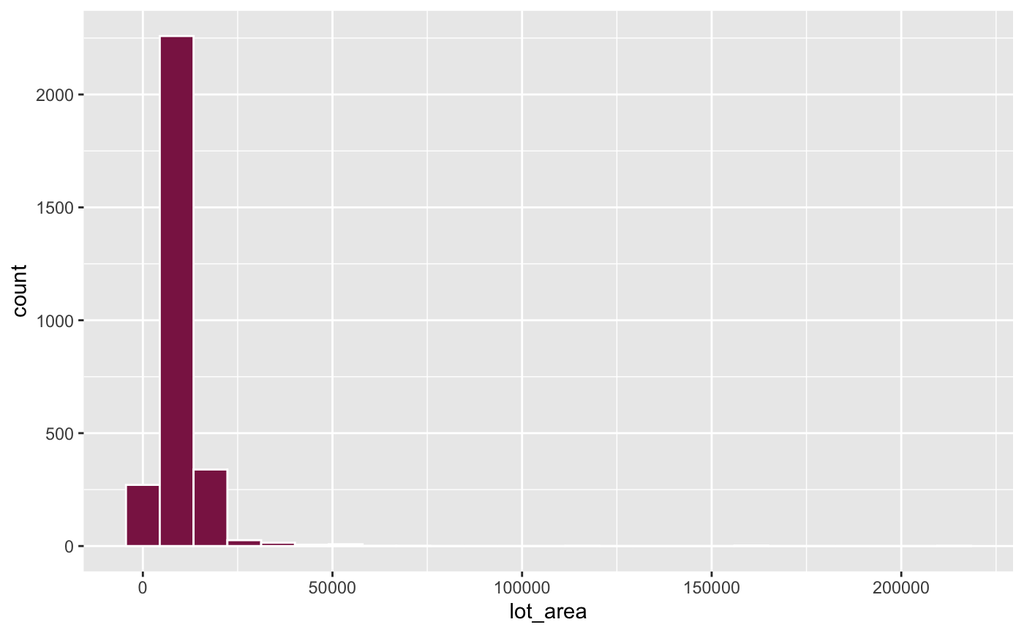

```r
ames %>%
  ggplot() +
  aes(x = lot_area) +
  geom_histogram(col = "white", bins = 25, fill = "violetred4")
```

A couple of outliers are skewing the data - making it appear right-skewed.

## Task 3.

Compute and visualise a bootstrap sampling distribution for the mean(lot_area) of the sold houses.

```r
ames_summary <- ames %>%
  summarise(
    num = n(),
    mean = mean(lot_area),
    sd = sd(lot_area)
  )
ames_summary
```

[output not shown]

```r
# Create a bootstrap sample with 1000 means in samples of 100
bootstrap_resample_100 <- ames %>%
  rep_sample_n(size = 100, replace = TRUE, reps = 1000) %>%
  dplyr::summarise(
    mean_lot_area = mean(lot_area)
  )

bootstrap_resample_100
```

[output not shown]

```r
bootstrap_resample_100 %>%
  ggplot() +
  aes(x = mean_lot_area) +
  geom_histogram(col = "white", bins = 25, fill = "violetred4")
```

[output not shown]

## Task 4.

Use your bootstrap distribution to calculate a 95% CI for mean(lot_area), and visualise it on the distribution

```r
ci_95 <- bootstrap_resample_100 %>%
  summarise(mean = mean(mean_lot_area),
            lower_bound = quantile(mean_lot_area, probs = 0.025),
            upper_bound = quantile(mean_lot_area, probs = 0.975))

ci_95
```

[output not shown]

## Task 5.

You would like to know the mean(lot_area) of the sold houses with higher confidence. Calculate the 99% CI for this variable (you can re-use your bootstrap distribution from above). Is it narrower or broader than the 95% CI? Does that make sense?

```r
ci_99 <- bootstrap_resample_100 %>%
  summarise(mean = mean(mean_lot_area),
            lower_bound = quantile(mean_lot_area, probs = 0.005),
            upper_bound = quantile(mean_lot_area, probs = 0.995))

ci_99
```

[output not shown]

## Task 6.

Calculate the point estimate of the mean(lot_area)

```r
summary_bootstrap_resample_100 <- bootstrap_resample_100 %>%
  ungroup() %>%
  summarise(
    mean_mean_lot_area = mean(mean_lot_area)
  )

summary_bootstrap_resample_100
```

[output not shown]

# 2 Extension

## Task 1.

Calculate a point estimate and 95% CI for the proportion of houses in the data built before 1920. Does the number of reps you use matter?
$$Investigate reps from 200 up to 50000, memory of your laptop permitting$$
.

```r
ames <- ames %>%
  mutate(before_1920 = case_when(year_built < 1921 ~ "pre 1920",
                                   TRUE ~ FALSE ),
  .after = year_built)
```

```
Error: Problem with `mutate()` column `before_1920`.
ℹ `before_1920 = case_when(year_built < 1921 ~ "pre 1920", TRUE ~ FALSE)`.
x must be a character vector, not a logical vector.
Run `rlang::last_error()` to see where the error occurred.
```

```r
# Create a bootstrap sample with 1000 means in samples of 100
bootstrap_resample_100 <- ames %>%
  rep_sample_n(size = 100, replace = TRUE, reps = 1000) %>%
  dplyr::summarise(
    mean_lot_area = mean(lot_area)
  )

bootstrap_resample_100
```

```r
bootstrap_resample <- ames %>%
  specify(response = before_1920, success = before_1920) %>%
  generate(reps = 500, type = "bootstrap") %>%
  calculate(stat = "prop")
```

```
Error in specify(., response = before_1920, success = before_1920) :
  object 'before_1920' not found
```

Hmmm - clearly not understanding what is being asked for here - and not completed.

Tried with some code Emily had written - but don’t think I was using it properly.